# UK Police Stop and Search: A Study of Bias and Disproportionality

2024-01-06

This is the repository where i host my code , data and a html file :https://github.com/KENZO666888/MY472-final-assignment.git

## 1.Introduction

This report employs data visualization techniques to investigate potential biases in stop and search practices by the UK police. The report is segmented into absolute and relative biases, aiming to determine if certain demographic groups defined by age, gender, and ethnicity are disproportionately affected. Additionally , it examines whether the UK police exhibit biases towards specific locations and times.

## 2.Data Sources

Office for National Statistics (ONS): This source offers demographic data for the UK population, primarily from the 2021 census, detailing total population figures across various demographic categories. (https://www.ons.gov.uk/census)

## 3.Data Processing

Cleaning and Aggregation: Absolute data processing involved cleaning the data to eliminate inconsistencies, standardizing formats, and aggregating to focus on key variables like age, gender, and ethnicity. The count function was utilized to ascertain the number of stop and search incidents per year and the total across 2020-2022 for various groups, subsequently determining the absolute proportion of searches for each demographic group.

Relative proportion calculation: Absolute data was then compared with ONS demographic statistics. This step involved aligning demographic categories between the two datasets and establishing mapping relationships to link different variables across both tables. Calculations were made to ascertain the relative stop and search probabilities for different ethnic groups , assessing whether some groups are more likely to be stopped and searched than others.

Temporal and Geographical Analysis: The data set includes mappings between geographic boundary coordinates and map data, as well as standardized 24-hour time format processing. The structure of these datasets is designed to analyze the continuous probability of being stopped and searched across different regions, times of day, and ages within the UK.

## 4.Analysis

Get uk police official website source data from API

```
##   year             force age_range                      outcome involved_person
## 1 2020 avon-and-somerset     18-24                                         TRUE
## 2 2020 avon-and-somerset     10-17 A no further action disposal            TRUE
## 3 2020 avon-and-somerset     10-17 A no further action disposal            TRUE
## 4 2020 avon-and-somerset     18-24                       Arrest            TRUE
## 5 2020 avon-and-somerset     18-24                                         TRUE
## 6 2020 avon-and-somerset     10-17                                         TRUE
##   self_defined_ethnicity gender
## 1                   <NA>   Male
## 2                   <NA>   Male
## 3                   <NA>   Male
## 4                   <NA>   Male
## 5                   <NA>   Male
## 6                   <NA>   Male
##                                         legislation
```

[output cut: 41 more lines]

Import UK population distribution from a file of census data obtained from ONS(We can see that the structure here is very confusing, which will be dealt with later.)

```
## # A tibble: 6 × 102
##   Population projections…¹  ...2  ...3  ...4  ...5  ...6  ...7  ...8  ...9 ...10
##   <chr>                    <dbl> <dbl> <dbl> <dbl> <dbl> <dbl> <dbl> <dbl> <dbl>
## 1 United Kingdom              NA    NA    NA    NA    NA    NA    NA    NA    NA
## 2 PERSONS, thousands          NA    NA    NA    NA    NA    NA    NA    NA    NA
## 3 <NA>                        NA    NA    NA    NA    NA    NA    NA    NA    NA
## 4 <NA>                        NA    NA    NA    NA    NA    NA    NA    NA    NA
## 5 <NA>                        NA    NA    NA    NA    NA    NA    NA    NA    NA
## 6 Ages                      2018  2019  2020  2021  2022  2023  2024  2025  2026
## # ℹ abbreviated name:
## #   ¹`Population projections by the Office for National Statistics`
## # ℹ 92 more variables: ...11 <dbl>, ...12 <dbl>, ...13 <dbl>, ...14 <dbl>,
## #   ...15 <dbl>, ...16 <dbl>, ...17 <dbl>, ...18 <dbl>, ...19 <dbl>,
## #   ...20 <dbl>, ...21 <dbl>, ...22 <dbl>, ...23 <dbl>, ...24 <dbl>,
## #   ...25 <dbl>, ...26 <dbl>, ...27 <dbl>, ...28 <dbl>, ...29 <dbl>,
## #   ...30 <dbl>, ...31 <dbl>, ...32 <dbl>, ...33 <dbl>, ...34 <dbl>, …
```

```
## # A tibble: 6 × 102
##   Population projections…¹  ...2  ...3  ...4  ...5  ...6  ...7  ...8  ...9 ...10
##   <chr>                    <dbl> <dbl> <dbl> <dbl> <dbl> <dbl> <dbl> <dbl> <dbl>
## 1 United Kingdom              NA    NA    NA    NA    NA    NA    NA    NA    NA
## 2 MALES, thousands            NA    NA    NA    NA    NA    NA    NA    NA    NA
## 3 <NA>                        NA    NA    NA    NA    NA    NA    NA    NA    NA
## 4 <NA>                        NA    NA    NA    NA    NA    NA    NA    NA    NA
## 5 <NA>                        NA    NA    NA    NA    NA    NA    NA    NA    NA
## 6 Ages                      2018  2019  2020  2021  2022  2023  2024  2025  2026
## # ℹ abbreviated name:
## #   ¹`Population projections by the Office for National Statistics`
## # ℹ 92 more variables: ...11 <dbl>, ...12 <dbl>, ...13 <dbl>, ...14 <dbl>,
## #   ...15 <dbl>, ...16 <dbl>, ...17 <dbl>, ...18 <dbl>, ...19 <dbl>,
## #   ...20 <dbl>, ...21 <dbl>, ...22 <dbl>, ...23 <dbl>, ...24 <dbl>,
## #   ...25 <dbl>, ...26 <dbl>, ...27 <dbl>, ...28 <dbl>, ...29 <dbl>,
## #   ...30 <dbl>, ...31 <dbl>, ...32 <dbl>, ...33 <dbl>, ...34 <dbl>, …
```

```
## # A tibble: 6 × 102
##   Population projections…¹  ...2  ...3  ...4  ...5  ...6  ...7  ...8  ...9 ...10
##   <chr>                    <dbl> <dbl> <dbl> <dbl> <dbl> <dbl> <dbl> <dbl> <dbl>
## 1 United Kingdom              NA    NA    NA    NA    NA    NA    NA    NA    NA
## 2 FEMALES, thousands          NA    NA    NA    NA    NA    NA    NA    NA    NA
## 3 <NA>                        NA    NA    NA    NA    NA    NA    NA    NA    NA
## 4 <NA>                        NA    NA    NA    NA    NA    NA    NA    NA    NA
## 5 <NA>                        NA    NA    NA    NA    NA    NA    NA    NA    NA
## 6 Ages                      2018  2019  2020  2021  2022  2023  2024  2025  2026
## # ℹ abbreviated name:
## #   ¹`Population projections by the Office for National Statistics`
## # ℹ 92 more variables: ...11 <dbl>, ...12 <dbl>, ...13 <dbl>, ...14 <dbl>,
## #   ...15 <dbl>, ...16 <dbl>, ...17 <dbl>, ...18 <dbl>, ...19 <dbl>,
## #   ...20 <dbl>, ...21 <dbl>, ...22 <dbl>, ...23 <dbl>, ...24 <dbl>,
## #   ...25 <dbl>, ...26 <dbl>, ...27 <dbl>, ...28 <dbl>, ...29 <dbl>,
## #   ...30 <dbl>, ...31 <dbl>, ...32 <dbl>, ...33 <dbl>, ...34 <dbl>, …
```

# 4.1 Total trend

Summarize the year data table based on the source data table

```
## # A tibble: 4 × 2
##    year total_cases
##   <int>       <int>
## 1  2020       47244
## 2  2021      522738
## 3  2022      462241
## 4  2023      390212
```

Make data visualization based on year table information(Because there is only data for December in 2020, the data for 2020 is deleted here)

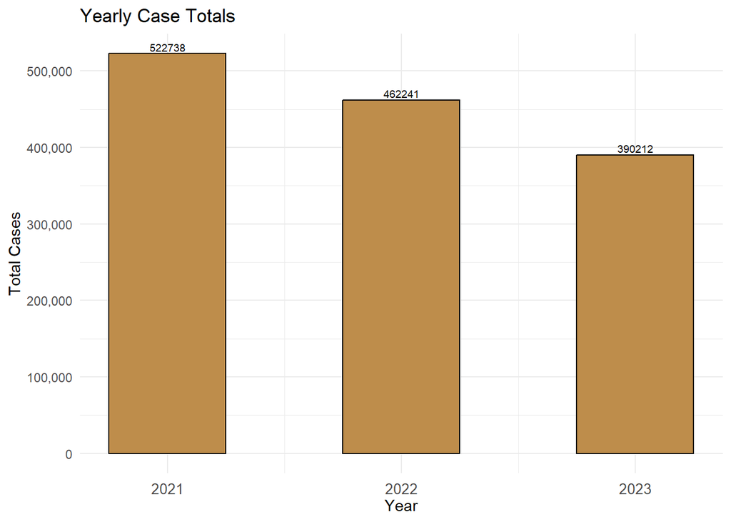

# Analysis for total trend:

Judging from the total number of cases, the number has gradually declined since 2021, indicating that the police’s willingness to search and stop is declining under the influence of policies.

# 4.2 Geographical bias

Data processing produces frequency tables broken down by geography

```
## # A tibble: 4 × 40
##   year      `avon-and-somerset` bedfordshire cambridgeshire cheshire
##   <chr>                   <int>        <int>          <int>    <int>
## 1 2020                      675          262            240      411
## 2 2021                     8005         3229           2970     5204
## 3 2022                     6430         4131           2884     9609
## 4 2020-2022               15110         7622           6094    15224
## # ℹ 35 more variables: `city-of-london` <int>, cleveland <int>, cumbria <int>,
## #   derbyshire <int>, `devon-and-cornwall` <int>, dorset <int>, durham <int>,
## #   essex <int>, gloucestershire <int>, hampshire <int>, hertfordshire <int>,
## #   humberside <int>, kent <int>, lancashire <int>, leicestershire <int>,
## #   lincolnshire <int>, merseyside <int>, metropolitan <int>, norfolk <int>,
## #   `north-wales` <int>, northamptonshire <int>, northumbria <int>,
## #   nottinghamshire <int>, `south-wales` <int>, `south-yorkshire` <int>, …
```

```
## # A tibble: 39 × 5
##    force               `2020`  `2021`  `2022` `2020-2022`
##    <chr>                <dbl>   <dbl>   <dbl>       <dbl>
##  1 avon-and-somerset  0.0143  0.0153  0.0139      0.0146
##  2 bedfordshire       0.00555 0.00618 0.00894     0.00738
##  3 cambridgeshire     0.00508 0.00568 0.00624     0.00590
##  4 cheshire           0.00870 0.00996 0.0208      0.0147
##  5 city-of-london     0.00472 0.00487 0.00502     0.00493
##  6 cleveland          0.0121  0.0120  0.0142      0.0130
##  7 cumbria            0.00637 0.00463 0.00728     0.00590
##  8 derbyshire         0.00417 0.00495 0.00508     0.00497
##  9 devon-and-cornwall 0.0143  0.0119  0.0121      0.0121
## 10 dorset             0.00404 0.00436 0.00418     0.00427
## # ℹ 29 more rows
```

Generate total and yearly pie charts to observe the dynamics of caseloads and total distribution by geography

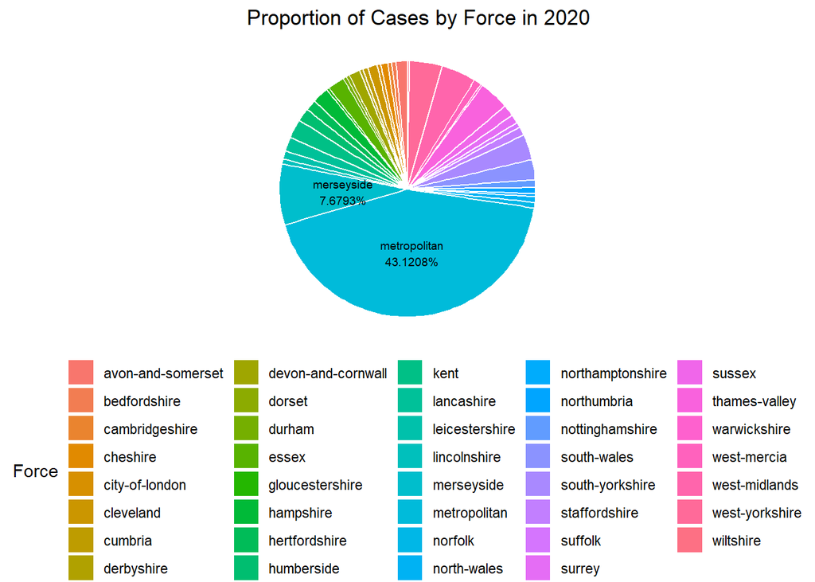

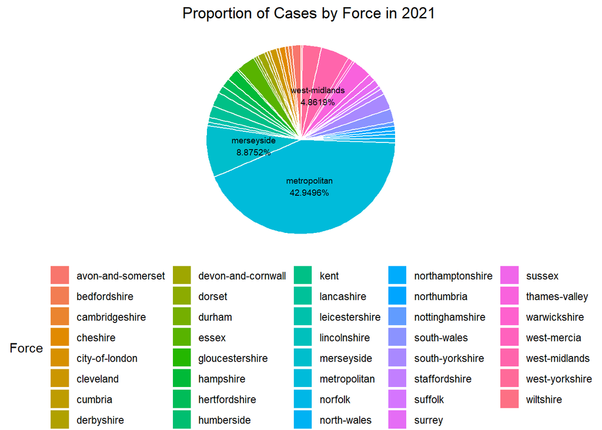

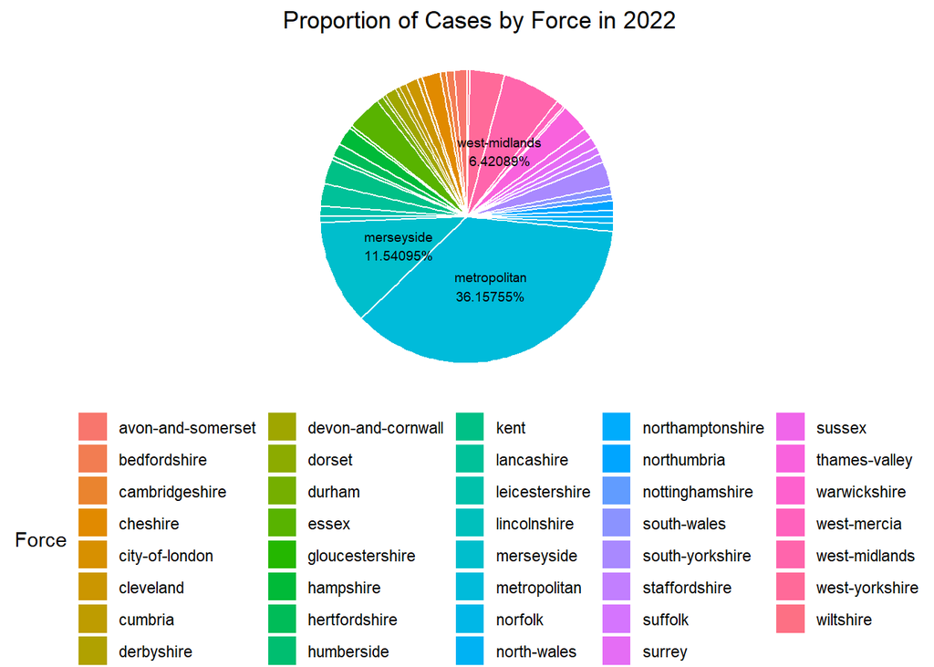

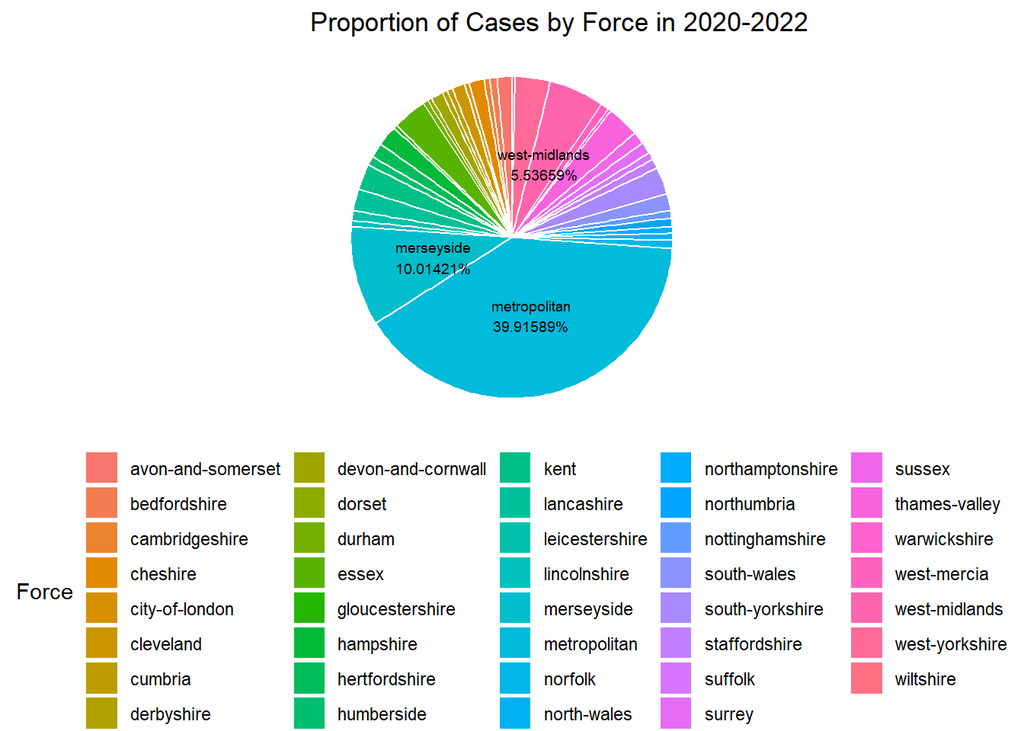

Draw a map of the UK divided by force through the kml file, and draw the distribution of the number of cases in these areas

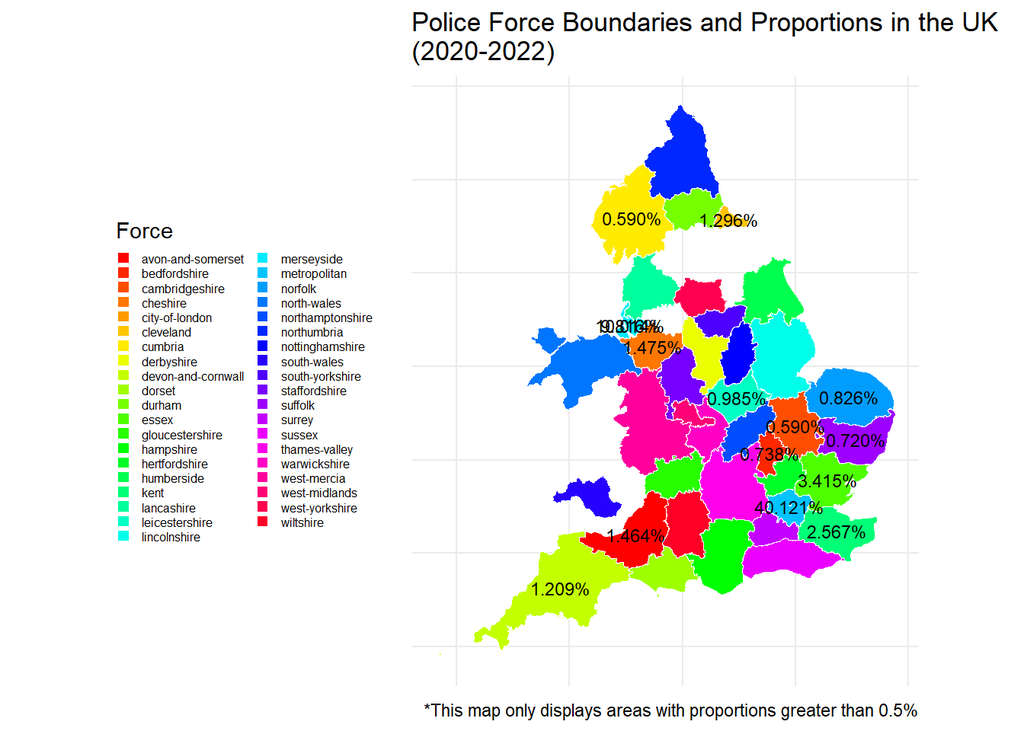